# Assignment - Week 02

Flurin Schindele

2026-02-28

```r
suppressPackageStartupMessages({
  library(AnnotationHub) # to fetch genomes, annotations, etc.
  library(ensembldb)     # to manipulate ensembl gene annotations
  library(GenomicRanges) # data structure for genomic ranges
  library(epiwraps)      # visualization
})
```

## Finding annotation data using `AnnotationHub`

```r
ah <- AnnotationHub()
```

```
## snapshotDate(): 2025-04-08
```

```r
query_results <- query(ah, c("Mus Musculus", "GRCm38", "102", "EnsDB"))
query_results
```

```
## AnnotationHub with 1 record
## # snapshotDate(): 2025-04-08
## # names(): AH89211
## # $dataprovider: Ensembl
## # $species: Mus musculus
## # $rdataclass: EnsDb
## # $rdatadateadded: 2020-10-27
## # $title: Ensembl 102 EnsDb for Mus musculus
## # $description: Gene and protein annotations for Mus musculus based on Ensem...
## # $taxonomyid: 10090
## # $genome: GRCm38
## # $sourcetype: ensembl
## # $sourceurl: http://www.ensembl.org
## # $sourcesize: NA
## # $tags: c("102", "AHEnsDbs", "Annotation", "EnsDb", "Ensembl", "Gene",
## #   "Protein", "Transcript")
## # retrieve record with 'object[["AH89211"]]'
```

```r
mm_ensdb <- ah[[rev(query_results$ah_id)[1]]]
```

```
## loading from cache
```

```r
mm_ensdb <- ah[["AH89211"]]
```

```
## loading from cache
```

```r
mm_ensdb
```

```
## EnsDb for Ensembl:
## |Backend: SQLite
## |Db type: EnsDb
## |Type of Gene ID: Ensembl Gene ID
## |Supporting package: ensembldb
## |Db created by: ensembldb package from Bioconductor
## |script_version: 0.3.6
## |Creation time: Sun Dec 20 12:15:16 2020
## |ensembl_version: 102
## |ensembl_host: localhost
## |Organism: Mus musculus
## |taxonomy_id: 10090
## |genome_build: GRCm38
## |DBSCHEMAVERSION: 2.1
## | No. of genes: 56305.
## | No. of transcripts: 144778.
## |Protein data available.
```

```r
query_results <- query(ah, c("Mus Musculus", "GRCm38", "dna_sm", "2bit"))
mcols(query_results)[, c("title", "genome", "rdatadateadded")]
```

```
## DataFrame with 19 rows and 3 columns
##                          title      genome rdatadateadded
##                    <character> <character>    <character>
## AH49775 Mus_musculus.GRCm38...      GRCm38     2015-12-28
## AH50120 Mus_musculus.GRCm38...      GRCm38     2015-12-29
## AH50611 Mus_musculus.GRCm38...      GRCm38     2016-05-03
## AH51299 Mus_musculus.GRCm38...      GRCm38     2016-08-15
## AH51645 Mus_musculus.GRCm38...      GRCm38     2016-11-03
## ...                        ...         ...            ...
## AH70177 Mus_musculus.GRCm38...   GRCm38.p6     2019-04-29
## AH77927 Mus_musculus.GRCm38...   GRCm38.p6     2019-10-29
## AH82549 Mus_musculus.GRCm38...   GRCm38.p6     2020-04-27
## AH84787 Mus_musculus.GRCm38...   GRCm38.p6     2020-10-26
## AH88477 Mus_musculus.GRCm38...   GRCm38.p6     2020-10-27
```

This way we have 19 records and there is no clear difference other than the release date. Maybe querying for the version number (102) narrows it down.

```r
query_results <- query(ah, c("Mus Musculus", "GRCm38", "dna_sm", "2bit", "102"))
query_results
```

```
## AnnotationHub with 1 record
## # snapshotDate(): 2025-04-08
## # names(): AH88477
## # $dataprovider: Ensembl
## # $species: mus musculus
## # $rdataclass: TwoBitFile
## # $rdatadateadded: 2020-10-27
## # $title: Mus_musculus.GRCm38.dna_sm.primary_assembly.2bit
## # $description: TwoBit DNA sequence for mus musculus
## # $taxonomyid: 10090
## # $genome: GRCm38.p6
## # $sourcetype: FASTA
## # $sourceurl: ftp://ftp.ensembl.org/pub/release-102/fasta/mus_musculus/dna/M...
## # $sourcesize: NA
## # $tags: c("TwoBit", "ensembl", "sequence", "2bit", "FASTA")
## # retrieve record with 'object[["AH88477"]]'
```

```r
mm_genseq <- ah[[rev(query_results$ah_id)[1]]]
```

```
## loading from cache
```

```r
mm_genseq
```

```
## TwoBitFile object
## resource: /Users/flurinschindele/Library/Caches/org.R-project.R/R/AnnotationHub/34ec7a593786_95223
```

When looking for the drosophila genome sequence there are again multiple entries so we will choose the most recent (using the `tail` function we specify the last entry).

```r
query_results <- query(ah,
  c("drosophila melanogaster", "BDGP6", "dna_sm", "2bit")
)
mcols(query_results)[, c("title", "genome", "rdatadateadded")]
```

```
## DataFrame with 24 rows and 3 columns
##                           title      genome rdatadateadded
##                     <character> <character>    <character>
## AH49674  Drosophila_melanogas..       BDGP6     2015-12-28
## AH50019  Drosophila_melanogas..       BDGP6     2015-12-29
## AH50510  Drosophila_melanogas..       BDGP6     2016-05-03
## AH51198  Drosophila_melanogas..       BDGP6     2016-08-15
## AH51544  Drosophila_melanogas..       BDGP6     2016-11-03
## ...                         ...         ...            ...
## AH90691  Drosophila_melanogas..    BDGP6.32     2020-10-27
## AH92960  Drosophila_melanogas..    BDGP6.32     2021-05-17
## AH99424  Drosophila_melanogas..    BDGP6.32     2021-10-20
## AH103729 Drosophila_melanogas..    BDGP6.32     2022-04-21
## AH106160 Drosophila_melanogas..    BDGP6.32     2022-04-25
```

```r
dm_genseq <- ah[[tail(rev(query_results$ah_id)[1])]]
```

```
## loading from cache
```

```r
dm_genseq
```

```
## TwoBitFile object
## resource: /Users/flurinschindele/Library/Caches/org.R-project.R/R/AnnotationHub/4135243a0f35_112906
```

## Exploring mouse Ensembl data

First we want to look at protein-coding genes.

```r
protein_genes <- genes(mm_ensdb)[
  genes(mm_ensdb)$gene_biotype == "protein_coding"
]
```

There are 22287 gene ids and 21964 gene symbols for protein-coding genes in the database. Some gene symbols are therefore not unique.

```r
head(protein_genes$gene_id)
```

```
## [1] "ENSMUSG00000051951" "ENSMUSG00000025900" "ENSMUSG00000025902"
## [4] "ENSMUSG00000033845" "ENSMUSG00000025903" "ENSMUSG00000104217"
```

```r
length(protein_genes$gene_id)
```

```
## [1] 22287
```

```r
length(unique(protein_genes$gene_id))
```

```
## [1] 22287
```

```r
head(protein_genes$symbol)
```

```
## [1] "Xkr4"    "Rp1"     "Sox17"   "Mrpl15"  "Lypla1"  "Gm37988"
```

```r
length(protein_genes$symbol)
```

```
## [1] 22287
```

```r
length(unique(protein_genes$symbol))
```

```
## [1] 21964
```

We can now query for all exons that belong to protein-coding genes and group them by transcript. By summing the width of the exons we get the length of the spliced transcripts.

```r
mm_exons <- exonsBy(mm_ensdb,
  by = "tx",
  filter = ~gene_biotype == "protein_coding"
)

head(width(mm_exons))
```

```
## IntegerList of length 6
## [["ENSMUST00000000001"]] 259 43 142 158 129 130 154 210 2037
## [["ENSMUST00000000003"]] 215 140 68 111 102 52 214
## [["ENSMUST00000000010"]] 602 1972
## [["ENSMUST00000000028"]] 169 195 60 93 138 144 56 ... 162 139 84 119 77 67 127
## [["ENSMUST00000000033"]] 109 163 149 3287
## [["ENSMUST00000000049"]] 115 177 97 77 189 180 198 157
```

```r
protein_tx_spliced_len <- sum(width(mm_exons))
head(protein_tx_spliced_len)
```

```
## ENSMUST00000000001 ENSMUST00000000003 ENSMUST00000000010 ENSMUST00000000028
##               3262                902               2574               2143
## ENSMUST00000000033 ENSMUST00000000049
##               3708               1190
```

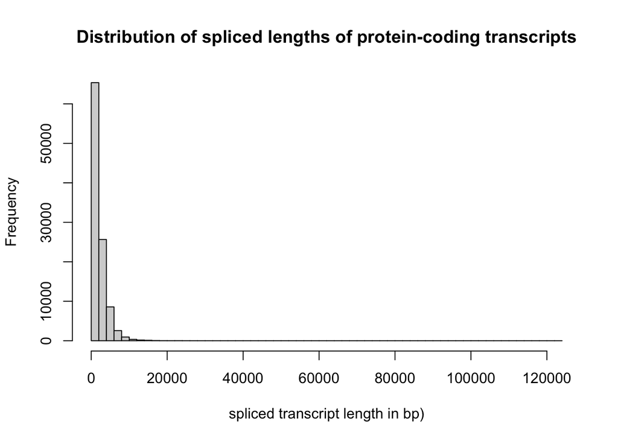

```r
hist(protein_tx_spliced_len,
  breaks = 50,
  main = "Distribution of spliced lengths of protein-coding transcripts",
  xlab = "spliced transcript length in bp)"
)
```

```r
head(sort(protein_tx_spliced_len, decreasing = TRUE), 10)
```

```
## ENSMUST00000020488 ENSMUST00000099981 ENSMUST00000111882 ENSMUST00000111846
##             123179             107355             101674             100404
## ENSMUST00000011934 ENSMUST00000053033 ENSMUST00000215295 ENSMUST00000114694
##              81999              40378              27908              26901
## ENSMUST00000238536 ENSMUST00000233317
##              26737              25851
```

Few transcripts are very long which skews the distribution and makes the plot not very informative. The longest transcript (ENSMUST00000020488) is 123’179 bps long. Interestingly, the last exon - exon 4 - makes up most of the transcript and is 122’802 bps long ([source](https://www.ensembl.org/Mus_musculus/Transcript/Exons?db=core;g=ENSMUSG00000020255;r=10:83196085-83324369;t=ENSMUST00000020488)). This can also be seen in the diagram below from the ensembl website. Filled boxes mark translated regions and unfilled boxes show UTRs.

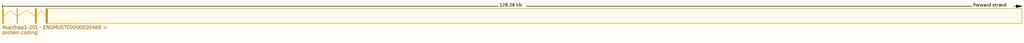

ENSMUST00000020488 transcript structure (source: Ensembl). Filled boxes mark translated regions, unfilled boxes show UTRs.

The coding region is only 558 bps long which seems reasonable.

```r
cds <- cdsBy(mm_ensdb, by = "tx", filter = TxIdFilter("ENSMUST00000020488"))
sum(width(cds[["ENSMUST00000020488"]]))
```

```
## [1] 558
```

In order to visualize the transcript length distribution a bit more reasonably we can perform a log-transform of the data.

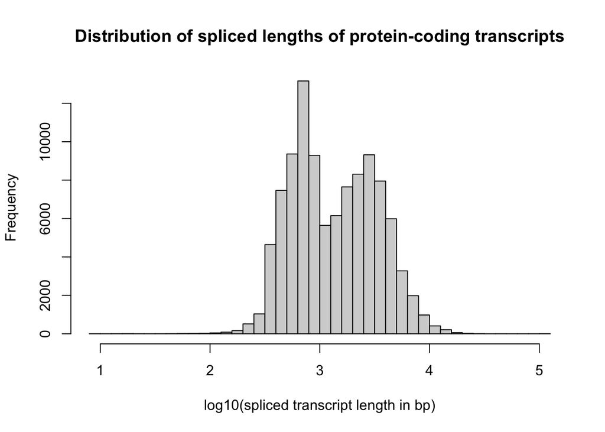

```r
hist(log10(protein_tx_spliced_len),
  breaks = 50,
  main = "Distribution of spliced lengths of protein-coding transcripts",
  xlab = "log10(spliced transcript length in bp)"
)
```